# Desafío 1: Tetris

Informática 2 - C++

Cristian Rivera González

2026-03-13

**Universidad de Antioquia — Facultad de Ingeniería**

**Ingeniería de Telecomunicaciones**

**Informática II — Semestre 2026-1**

## 1. Contextualización del Problema

El desafío consiste en implementar una versión simplificada del juego Tetris que funcione completamente desde la consola. A diferencia del Tetris que todos conocemos, esta versión no va a tener animaciones en tiempo real ni colores; en cambio, el juego funciona por turnos: el sistema muestra el tablero, el jugador elige una acción (mover, rotar o bajar la pieza), y el tablero se actualiza.

Lo que hace especial este proyecto es que el tablero y las piezas deben manejarse usando **operaciones a nivel de bits**, que es una forma de representar y manipular datos directamente en su forma binaria (ceros y unos). Esto significa que en lugar de guardar cada celda del tablero como un número entero normal, se va a usar cada bit individual para representar si una celda está ocupada o no. Por ejemplo, si el tablero tiene 8 columnas de ancho, una sola fila puede representarse con un solo byte (8 bits), donde un `1` indica que la celda está ocupada y un `0` que está vacía.

Además del manejo de bits, el proyecto requiere usar **memoria dinámica** para construir el tablero en tiempo de ejecución, ya que el usuario define el tamaño al inicio del programa. Esto significa que no podemos declarar el tablero con un tamaño fijo en el código; tenemos que reservar la memoria con `new` y liberarla con `delete` al final.

En resumen, el proyecto integra casi todos los temas que hemos visto en el curso: variables, estructuras de control, arreglos, funciones, apuntadores, operadores de bits y memoria dinámica.

## 2. Análisis del Problema

### 2.1 ¿Qué necesita el programa?

Pensando en el problema, identifico que el programa necesita manejar principalmente tres cosas:

1. **El tablero:** una cuadrícula de filas y columnas donde caen las piezas.
2. **Las piezas:** los 7 tetriminos clásicos (I, O, T, S, Z, J, L), de los cuales hay que implementar al menos 5.
3. **La lógica del juego:** mover piezas, detectar colisiones, limpiar filas llenas y detectar el game over.

### 2.2 Representación del tablero con bits

Esta es la parte más difícil del proyecto. La idea es que cada fila del tablero se represente como un número entero, donde cada bit corresponde a una columna. Si el tablero tiene 8 columnas de ancho, cada fila es un `uint8_t` (un entero sin signo de 8 bits). Si el tablero tiene 16 columnas, cada fila sería un `uint16_t`, y así sucesivamente.

Por ejemplo, una fila donde las columnas 0, 2 y 5 están ocupadas se vería así en binario:

```
Columnas: 7 6 5 4 3 2 1 0
Bits:     0 0 1 0 0 1 0 1   →  valor decimal: 37
```

> **Nota:** Todavía no tengo completamente claro cómo voy a manejar tableros cuyo ancho sea mayor a 32 columnas, porque los tipos enteros estándar tienen un límite de bits. Por ahora asumo que el tablero no va a superar 32 columnas de ancho, así que usaría `uint32_t` como tipo de dato para cada fila. Esto es algo que debo revisar mejor durante la implementación.

El tablero completo entonces sería un **arreglo dinámico de punteros**, donde cada elemento es una fila representada por el tipo de entero correspondiente al ancho.

### 2.3 Representación de las piezas con bits

Cada pieza del Tetris ocupa una matriz pequeña (por ejemplo, 4x4 o 3x3). La idea es representar cada pieza como un número entero de 16 bits, donde cada grupo de 4 bits representa una fila de la pieza.

Por ejemplo, la pieza I horizontal:

```
1 1 1 1   →  fila 0: 1111 = 0xF
0 0 0 0   →  fila 1: 0000 = 0x0
0 0 0 0   →  fila 2: 0000 = 0x0
0 0 0 0   →  fila 3: 0000 = 0x0

Representación: 0xF000
```

La pieza T:

```
0 1 0   →  010
1 1 1   →  111
0 0 0   →  000

Representación: pensaría usar algo similar con un uint16_t
```

> **Nota:** Todavía no estoy seguro de si usar un `uint16_t` por pieza es suficiente para todas las piezas o si algunas necesitarían más bits. Tampoco tengo del todo claro cómo voy a hacer las rotaciones usando bits; sé que tiene que ver con desplazamientos y máscaras, pero aún debo trabajar más en esa parte.

### 2.4 Detección de colisiones

La detección de colisiones se haría comparando los bits de la pieza con los bits del tablero en la posición donde va a caer. Si hacemos un AND (`&`) entre los bits de la fila de la pieza y los bits de la fila del tablero, el resultado debería ser `0` si no hay colisión. Si el resultado es diferente de `0`, significa que algún bit coincide y hay colisión.

También hay que verificar que la pieza no se salga de los bordes del tablero, lo cual implica revisar si los bits de la pieza, después de desplazarse, se salen del rango de columnas válidas.

### 2.5 Limpieza de filas

Cuando una fila del tablero tiene todos sus bits en `1`, significa que está completamente llena y debe eliminarse. Para verificarlo, podría comparar la fila con una máscara que tenga todos los bits del ancho del tablero en `1`. Si `fila & mascara == mascara`, la fila está llena.

Cuando se elimina una fila, todas las filas superiores deben bajar una posición. Esto lo haría moviendo los punteros del arreglo, o simplemente copiando los valores de cada fila hacia la posición siguiente.

> **Nota:** No tengo claro todavía si es más eficiente mover los punteros o copiar los valores. Intuyo que mover los punteros sería más rápido, pero debo pensarlo mejor.

### 2.6 Rotación de piezas

La rotación es lo que más me preocupa porque implica transformar la representación en bits de una pieza para que quede girada 90 grados. Por ahora tengo la idea de que podría tener guardadas las 4 orientaciones posibles de cada pieza como constantes, y simplemente cambiar entre ellas cuando el usuario rote. Esto sería más sencillo que calcular la rotación en tiempo real con bits.

### 2.7 Memoria dinámica

El tablero se va a crear con `new` al inicio del programa, una vez que el usuario ingrese las dimensiones. Cada fila será un elemento del arreglo dinámico. Al terminar el programa, hay que liberar toda esa memoria con `delete[]`.

También estoy pensando si las piezas deben crearse dinámicamente o si con variables locales es suficiente. Por ahora creo que las piezas pueden ser variables locales dentro de la función del juego, ya que no necesitan persistir más allá de su turno.

### 2.8 Funciones principales identificadas

Pensando en cómo organizar el código, identifico las siguientes funciones necesarias:

- `crearTablero(ancho, alto)` → reserva memoria dinámica para el tablero.
- `liberarTablero(tablero, alto)` → libera la memoria al terminar.
- `imprimirTablero(tablero, ancho, alto)` → muestra el tablero en consola.
- `verificarColision(tablero, pieza, fila, columna)` → comprueba si la pieza puede moverse.
- `fijarPieza(tablero, pieza, fila, columna)` → “pega” la pieza al tablero.
- `limpiarFilas(tablero, ancho, alto)` → elimina filas completas.
- `verificarGameOver(tablero, ancho)` → detecta si el juego terminó.
- `rotar(pieza)` → rota la pieza 90 grados.

> **Nota:** Probablemente me falten funciones o algunas de estas terminen dividiéndose en más partes durante la implementación.

## 3. Diseño Preliminar

### 3.1 Estructura general del programa

El programa tendrá un flujo principal muy parecido a los programas con menú que ya hemos hecho en el curso, pero con un ciclo de juego en lugar de un menú de opciones:

1. Pedir dimensiones del tablero al usuario y validarlas.
2. Crear el tablero dinámicamente.
3. Generar la primera pieza.
4. Entrar al ciclo principal del juego:
   - Mostrar el tablero con la pieza actual.
   - Pedir acción al usuario.
   - Aplicar el movimiento si es válido.
   - Si la pieza no puede bajar más, fijarla al tablero.
   - Limpiar filas llenas.
   - Generar nueva pieza.
   - Verificar game over.
5. Al terminar, liberar la memoria y mostrar mensaje de fin.

### 3.2 Tipos de datos seleccionados

| Elemento | Tipo de dato | Justificación |
| --- | --- | --- |
| Fila del tablero (ancho ≤ 8) | `uint8_t*` | 8 bits = 8 columnas, máximo ahorro |
| Fila del tablero (ancho ≤ 16) | `uint16_t*` | 16 bits = 16 columnas |
| Fila del tablero (ancho ≤ 32) | `uint32_t*` | 32 bits = 32 columnas |
| Tablero completo | `uint8_t**` | Arreglo dinámico de punteros a filas |
| Representación de pieza | `uint16_t` | 16 bits para una matriz 4x4 |
| Posición de pieza | `int` | Fila y columna actuales |
| Tipo de pieza | `int` | Índice del 0 al 6 para cada tetrimino |

> **Nota:** Estoy pensando si el tablero debería ser `uint8_t**` siempre o si debería cambiar según el ancho. Por ahora voy a asumir que el ancho máximo será 32 para simplificar, pero esto podría cambiar.

### 3.3 Piezas definidas

Las 5 piezas mínimas que voy a implementar son I, O, T, S y Z. Si alcanza el tiempo, agregaré J y L. Cada pieza tendrá sus 4 orientaciones guardadas como constantes:

```cpp
// Pieza I — 4 orientaciones
uint16_t piezaI[4] = {
    0xF000,  // horizontal: 1111 0000 0000 0000
    0x8888,  // vertical:   1000 1000 1000 1000
    0xF000,  // igual a horizontal
    0x8888   // igual a vertical
};

// Pieza O — 1 orientación (cuadrado, no rota)
uint16_t piezaO[4] = {
    0xCC00,  // 1100 1100 0000 0000
    0xCC00,
    0xCC00,
    0xCC00
};
```

> **Nota:** Todavía debo calcular y verificar los valores exactos en hexadecimal para todas las piezas. Los valores que pongo aquí son aproximados y pueden tener errores; los confirmaré durante la implementación dibujando cada pieza en papel primero.

### 3.4 Diagrama de flujo preliminar

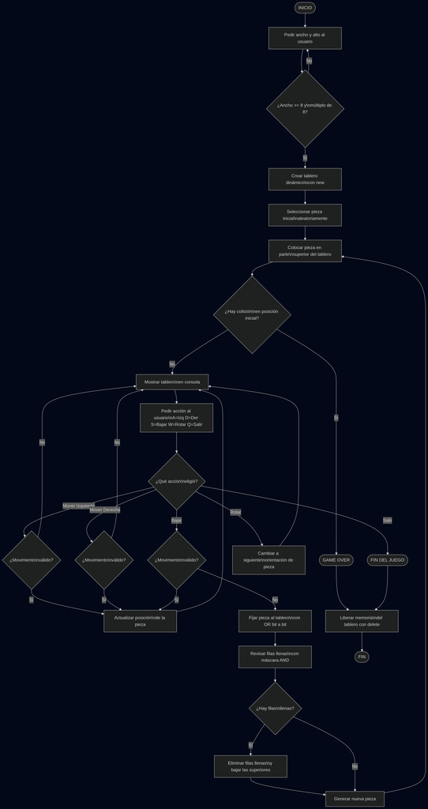

Diagrama de flujo del programa Tetris. Fuente: https://mermaid.js.org/

## 5. Problemas Anticipados y Dudas Pendientes

Durante el análisis encontré varios puntos que todavía no tengo del todo claros y que voy a tener que resolver durante la implementación:

1. **Rotación con bits:** Sé que debo usar desplazamientos y máscaras para rotar, pero calcular exactamente cómo hacer la rotación en bits de una pieza de 4x4 no lo tengo claro aún. Por ahora voy a guardar las 4 orientaciones como constantes.
2. **Ancho variable del tablero:** El tipo de dato de cada fila cambia según el ancho. Voy a pensar cómo manejar eso sin complicar demasiado el código, quizás usando `uint32_t` para todos los casos y simplemente ignorando los bits que sobren.
3. **Desplazamiento de la pieza sobre el tablero:** Cuando la pieza está en la columna 3, sus bits necesitan estar desplazados 3 posiciones. Tengo que asegurarme de hacer ese desplazamiento correctamente antes de comparar con los bits del tablero.
4. **Colisión con el borde derecho:** Si la pieza se desplaza muy a la derecha, sus bits podrían “desbordarse” más allá del ancho del tablero. Tengo que pensar cómo detectar ese caso con una máscara.
5. **Generación de piezas:** El enunciado no explica si las piezas deben generarse de forma aleatoria. Voy a asumir que sí, usando el operador módulo sobre un contador que incremente en cada turno, ya que no podemos usar librerías externas.